# Data Wrangling and Exploratory Data Analysis

### Setting up the connection

```r
library(tidyverse)
library(RSQLite)
db <- DBI::dbConnect(RSQLite::SQLite(), "lahman2016.sqlite")
DBI::dbListTables(db)
```

```
##  [1] "AllstarFull"         "Appearances"         "AwardsManagers"
##  [4] "AwardsPlayers"       "AwardsShareManagers" "AwardsSharePlayers"
##  [7] "Batting"             "BattingPost"         "CollegePlaying"
## [10] "Fielding"            "FieldingOF"          "FieldingOFsplit"
## [13] "FieldingPost"        "HallOfFame"          "HomeGames"
## [16] "Managers"            "ManagersHalf"        "Master"
## [19] "Parks"               "Pitching"            "PitchingPost"
## [22] "Salaries"            "Schools"             "SeriesPost"
## [25] "Teams"               "TeamsFranchises"     "TeamsHalf"
```

### Problem 1 Using SQL, write a query to compute the total payroll and winning percentage (number of wins / number of games * 100) for each team (that is, for each teamID and yearID combination). You should include other columns that will help when performing EDA later on (e.g., franchise ids, number of wins, number of games).

```sql
select Teams.teamID as teamID,
  sum(Salaries.salary) as total_payroll,
  (cast(sum(Teams.W) as float) / sum(Teams.G))*100 as win_percentage,
  sum(Teams.W) as total_wins,
  sum(Teams.G) as total_games
from Salaries
join Teams
on Salaries.teamID = Teams.teamID
and Salaries.yearID = Teams.yearID
where Salaries.yearID between 1990 and 2014
group by Teams.teamID
```

### Results

```r
payroll_df %>%
  head()
```

```
##   teamID total_payroll win_percentage total_wins total_games
## 1    ANA     468091973       50.82971      20339       40014
## 2    ARI    1209975228       49.36869      38709       78408
## 3    ATL    1810651930       56.94985      65293      114650
## 4    BAL    1569930553       47.84576      56991      119114
## 5    BOS    2365879129       53.81226      65468      121660
## 6    CAL     203235058       46.67785      16411       35158
```

# Exploratory data analysis

## Payroll distribution

### Problem 2. Write code to produce a plot (or plots) that shows the distribution of payrolls across teams conditioned on year (from 1990-2014). Note: you may create a single plot as long as the distributions for each year are clearly distinguishable (e.g., a single plot overlaying histograms is not OK).

```sql
select Salaries.yearID as year,
  Teams.teamID as team,
  sum(Salaries.salary) as payroll
from Salaries
join Teams
on Salaries.teamID = Teams.teamID
and Salaries.yearID = Teams.yearID
where year between 1990 and 2014
group by year, team
```

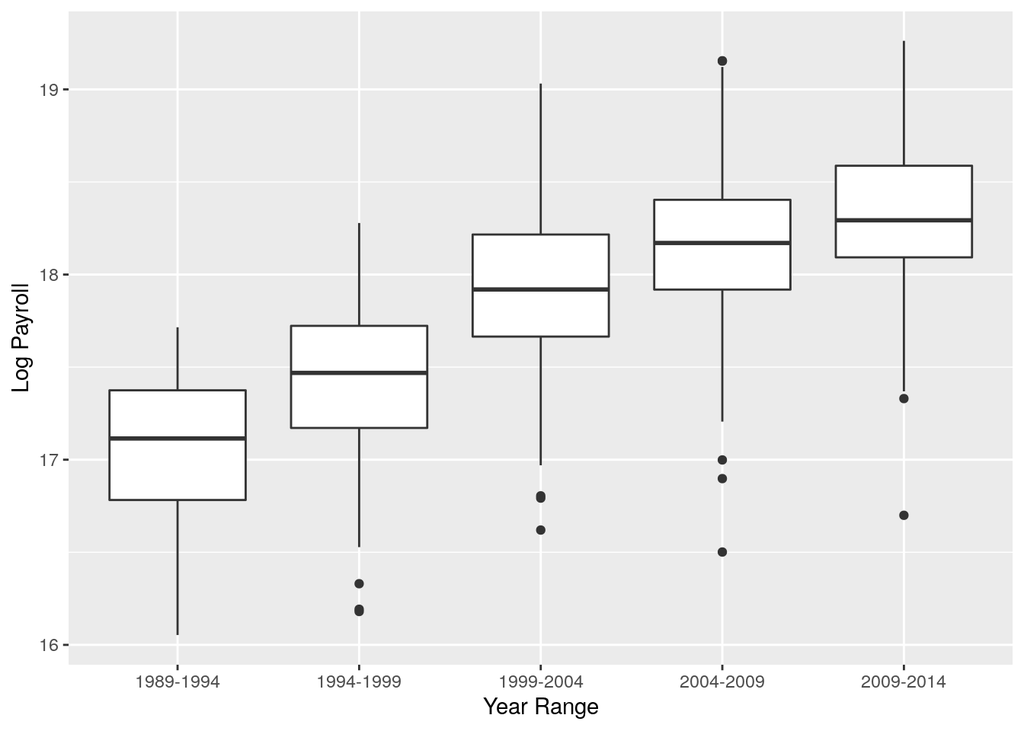

```r
library(ggplot2)

dist_df %>%
  group_by(team) %>%
  mutate(log_payroll = log(payroll)) %>%
  mutate(yearRange = ifelse(1989 < year & year <= 1994, paste("1989-1994"),
                ifelse(1994 < year & year <= 1999, paste("1994-1999"),
                ifelse(1999 < year & year <= 2004, paste("1999-2004"),
                ifelse(2004 < year & year <= 2009, paste("2004-2009"),
                       paste("2009-2014")))))) %>%
  ggplot(aes(x=yearRange, y=log_payroll)) +
  geom_boxplot() +
  labs(x="Year Range", y="Log Payroll")
```

### Problem 3. Write code to produce a plot (or plots) that specifically shows at least one of the statements you made in Question 1. For example, if you make a statement that there is a trend for payrolls to decrease over time, make a plot of a statistic for central tendency (e.g., mean payroll) vs. time to show that specifically.

The statement I am going to prove is that the maximum payrolls stopped increasing significantly after 2004. I did this by graphing strictly the max payrolls between the years 1990 and 2014. The graph clearly shows a steep decline in the slope of the graph after 2005, showing that the payrolls stopped increasing as sharply at that point.

```sql
select year, max(payroll) as max_payroll
from
  (select Salaries.yearID as year,
    Teams.teamID as team,
    sum(Salaries.salary) as payroll
  from Salaries
  join Teams
  on Salaries.teamID = Teams.teamID
  and Salaries.yearID = Teams.yearID
  where year between 1990 and 2014
  group by year, team)
group by year
```

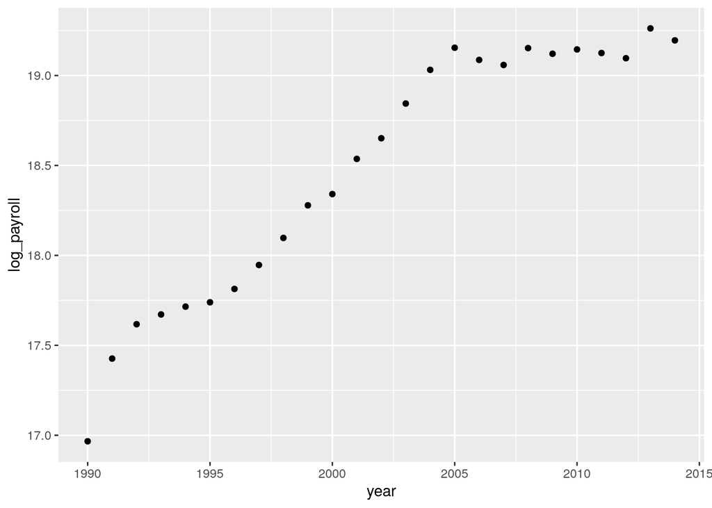

```r
max_df %>%
  mutate(log_payroll = log(max_payroll)) %>%
  ggplot(aes(x=year, y=log_payroll)) +
  geom_point()
```

# Correlation between payroll and winning percentage

### Problem 4. Write code to discretize year into five time periods (e.g., using the cut function with parameter breaks=5 (in R, bins=5 in python) and then make a scatterplot showing mean winning percentage (y-axis) vs. mean payroll (x-axis) for each of the five time periods. You could add a regression line (using geom_smooth(method=lm)) in each scatter plot to ease interpretation. Note: look at the discussion on faceting in the visualization EDA lecture notes.

```sql
select Salaries.yearID as year,
  Teams.teamID as team,
  (cast(sum(Teams.W) as float) / sum(Teams.G))*100 as win_percentage,
  sum(Salaries.salary) as payroll
from Salaries
join Teams
on Salaries.teamID = Teams.teamID
and Salaries.yearID = Teams.yearID
where year between 1990 and 2014
group by year, team
```

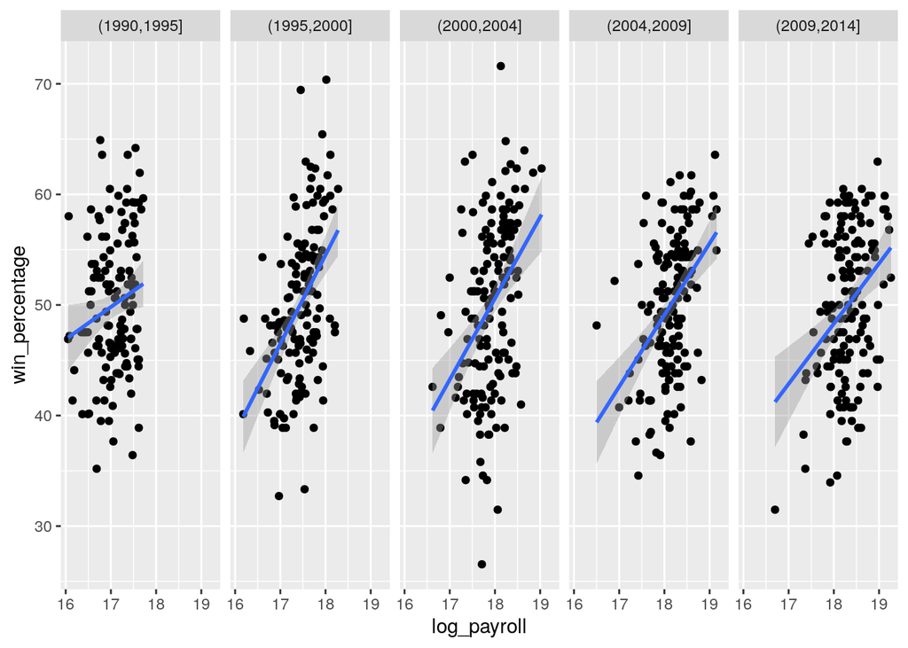

```r
winpay$year_range <- cut(winpay$year, breaks=5)
winpay %>%
  mutate(log_payroll = log(payroll)) %>%
  ggplot(aes(x=log_payroll, y=win_percentage)) +
  facet_grid(~year_range) +
  geom_point() +
  geom_smooth(method=lm)
```

```r
library(gridExtra)
```

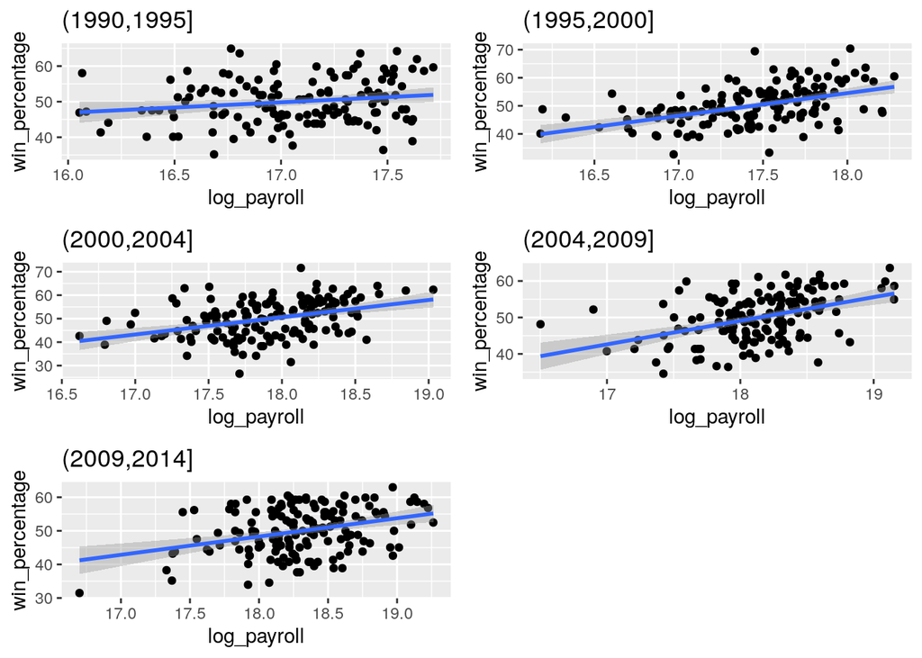

```r
data_ranges <- split(winpay, cut(winpay$year, breaks = 5))
p1 <- data_ranges$`(1990,1995]` %>%
  mutate(log_payroll = log(payroll)) %>%
  ggplot(aes(x=log_payroll, y=win_percentage)) +
  ggtitle('(1990,1995]') +
  geom_point() +
  geom_smooth(method=lm)
p2 <- data_ranges$`(1995,2000]` %>%
  mutate(log_payroll = log(payroll)) %>%
  ggplot(aes(x=log_payroll, y=win_percentage)) +
  ggtitle('(1995,2000]') +
  geom_point() +
  geom_smooth(method=lm)
p3 <- data_ranges$`(2000,2004]` %>%
  mutate(log_payroll = log(payroll)) %>%
  ggplot(aes(x=log_payroll, y=win_percentage)) +
  ggtitle('(2000,2004]') +
  geom_point() +
  geom_smooth(method=lm)
p4 <- data_ranges$`(2004,2009]` %>%
  mutate(log_payroll = log(payroll)) %>%
  ggplot(aes(x=log_payroll, y=win_percentage)) +
  ggtitle('(2004,2009]') +
  geom_point() +
  geom_smooth(method=lm)
p5 <- data_ranges$`(2009,2014]` %>%
  mutate(log_payroll = log(payroll)) %>%
  ggplot(aes(x=log_payroll, y=win_percentage)) +
  ggtitle('(2009,2014]') +
  geom_point() +
  geom_smooth(method=lm)

grid.arrange(p1, p2, p3, p4, p5, nrow=3)
```

#### Question 2. What can you say about team payrolls across these periods? Are there any teams that standout as being particularly good at paying for wins across these time periods? What can you say about the Oakland A’s spending efficiency across these time periods (labeling some points in the scatterplot can help interpretation).

I can say that as a general trend, win percentages have a positive increase as a team’s payroll increases, but there’s so much variance in these plots that it is hard to call this a causation relationship. It seems that the time period when these two variables were most strongly correlated was the 1995 to 2000 time period.